# Python

- 自学 Python 第12天
- 学习循环神经网络和迁移学习
- 本文参考了该[网址1](https://www.icourse163.org/learn/ZUCC-1206146808?tid=1450260446#/learn/content?type=detail&id=1214536607&cid=1218338126&replay=true)和[网址2](https://www.icourse163.org/learn/ZUCC-1206146808?tid=1450260446#/learn/content?type=detail&id=1214536596&sm=1)

```python
import jieba
```

```python
text="我是一名毕业于上海财经大学的博士研究生。"
text
```

```
'我是一名毕业于上海财经大学的博士研究生。'
```

```python
word_list=jieba.cut(text)
```

```python
print(word_list)
```

```
<generator object Tokenizer.cut at 0x000001C193B45548>
```

```python
list(word_list)
```

```
['我', '是', '一名', '毕业', '于', '上海财经大学', '的', '博士', '研究生', '。']
```

```python
##精确模式，与不带参数一样
word_list=jieba.cut(text,cut_all=False)
list(word_list)
```

```
['我', '是', '一名', '毕业', '于', '上海财经大学', '的', '博士', '研究生', '。']
```

```python
##全模式
word_list=jieba.cut(text,cut_all=True)
list(word_list)
```

```
['我',
 '是',
 '一名',
 '毕业',
 '于',
 '上海',
 '上海财经大学',
 '财经',
 '财经大学',
 '大学',
 '的',
 '博士',
 '研究',
 '研究生',
 '。']
```

```python
##搜索引擎模式
word_list=jieba.cut_for_search(text)
list(word_list)
```

```
['我',
 '是',
 '一名',
 '毕业',
 '于',
 '上海',
 '财经',
 '大学',
 '上海财经大学',
 '的',
 '博士',
 '研究',
 '研究生',
 '。']
```

```python
##返回一个列表，即不需要再用list显示结果
word_list=jieba.lcut(text)
word_list
```

```
['我', '是', '一名', '毕业', '于', '上海财经大学', '的', '博士', '研究生', '。']
```

```python
word_list=jieba.lcut_for_search(text)
word_list
```

```
['我',
 '是',
 '一名',
 '毕业',
 '于',
 '上海',
 '财经',
 '大学',
 '上海财经大学',
 '的',
 '博士',
 '研究',
 '研究生',
 '。']
```

### 将文本转化为数字，方式一就是onehot，但是其缺点是维度高（p=词汇数），稀疏，无法捕捉词汇的相关性，因为一个向量只有一个位置是非零。

### 方式2就是词嵌入，即将词汇嵌入到低维连续向量空间中，即将一个单词表示为一个连续的向量，现在已经有了很多已经训练好的表达方式，我们只需拿来用即可。

```python
import tensorflow as tf
import re
import string
import random as randint
```

```python
imdb = tf.keras.datasets.imdb
(train_data,train_labels),(test_data,test_labels)=imdb.load_data()
```

### 文本数据处理步骤

- 获取数据
- 文字分词，参考jieba
- 简历词索引表，给每个词一个数字索引编号
- 段落文字转化为次索引向量
- 段落文字转化为词嵌入矩阵

```python
x_train.shape
```

[output not shown]

```
(25000, 400)
```

```python
x_test.shape
```

```
(25000, 400)
```

# 猫狗大战: 迁移学习

### 数据可见[此网站](https://www.microsoft.com/en-us/download/confirmation.aspx?id=54765)

## 制作dataset数据集

- tensorflow提供了tf.data这一模块，包括了一套灵活的数据集构建API，能够快速高效的构建数据输入的流水线，尤其适用于大数据量场景。
- tf.data.Dataset类是tf.data的核心，提供看对数据集的高度封装；
- tf.data.Dataset由一系列的可迭代访问的元素组成，每个元素包含一个或多个张量；
- 用tf.data.Dataset.from_tensor_silces()是建立tf.data.Dataset的基本方法，适用于数据量小的情况；

## dataset数据集元素访问

```python
import tensorflow as tf
import numpy as np
import os
import matplotlib.pyplot as plt
```

```python
X = tf.constant([11,12,13,14,15])
Y = tf.constant([1,2,3,4,5])
dataset = tf.data.Dataset.from_tensor_slices((X,Y))
for x,y in dataset:
    print(y.numpy(),x.numpy())
```

```
1 11
2 12
3 13
4 14
5 15
```

```python
#因为数据集太大，我们只取前1001张图片，即总共2002张
def read_image_filenames(data_dir):
    cat_dir = data_dir+"Cat2/"
    dog_dir = data_dir+"Dog2/"
    #构建特征数据集，值为对应的图片文件名
    cat_filenames = tf.constant([cat_dir + fn for fn in os.listdir(cat_dir)])
    dog_filenames = tf.constant([dog_dir + fn for fn in os.listdir(dog_dir)])
    filenames = tf.concat([cat_filenames,dog_filenames],axis=-1)
    labels = tf.concat([
        tf.zeros(cat_filenames.shape,dtype = tf.int32),
        tf.ones(dog_filenames.shape,dtype = tf.int32)],
        axis = -1)
    return filenames, labels
```

```python
def decode_image_and_resize(filenames, label):
    image_string = tf.io.read_file(filenames)
    image_decoded = tf.image.decode_jpeg(image_string)
    image_resiezd = tf.image.resize(image_decoded, [224,224])/255.0

    return image_resiezd, label
```

### 建立猫狗大战的Datsset数据集

```python
train_data_dir = "D:/Gog_VS_Cat/PetImages/"
filenames, labels = read_image_filenames(train_data_dir)
dataset = tf.data.Dataset.from_tensor_slices((filenames, labels))
```

```python
sub_dataset = dataset.take(6)
for x,y in sub_dataset:
    print("filename:",x.numpy(),"label:",y.numpy())
```

```
filename: b'D:/Gog_VS_Cat/PetImages/Cat2/0.jpg' label: 0
filename: b'D:/Gog_VS_Cat/PetImages/Cat2/1.jpg' label: 0
filename: b'D:/Gog_VS_Cat/PetImages/Cat2/10.jpg' label: 0
filename: b'D:/Gog_VS_Cat/PetImages/Cat2/100.jpg' label: 0
filename: b'D:/Gog_VS_Cat/PetImages/Cat2/1000.jpg' label: 0
filename: b'D:/Gog_VS_Cat/PetImages/Cat2/1001.jpg' label: 0
```

```python
##读取数据并处理
dataset = dataset.map(
          map_func=decode_image_and_resize,
          num_parallel_calls = tf.data.experimental.AUTOTUNE)#并行处理文件
```

```python
##查看前几个样本
sub_dataset = dataset.take(2)
for x,y in sub_dataset:
    print(x.shape,y.shape)
```

```
(224, 224, 3) ()
(224, 224, 3) ()
```

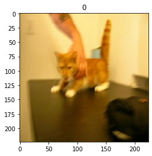

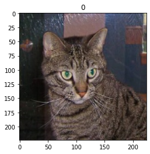

```python
import matplotlib.pyplot as plt
for x,y in sub_dataset:
    plt.title(y.numpy())
    plt.imshow(x.numpy())
    plt.show()
```

```python
buffer_size = 2002
dataset = dataset.shuffle(buffer_size)
dataset
```

```
<ShuffleDataset shapes: ((224, 224, None), ()), types: (tf.float32, tf.int32)>
```

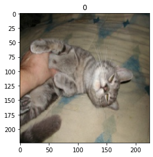

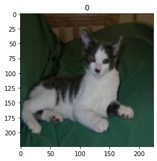

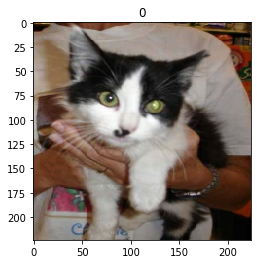

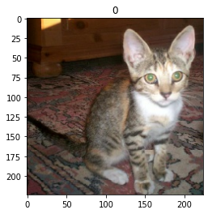

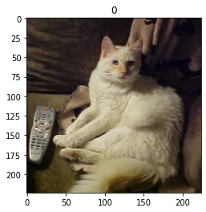

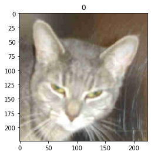

```python
sub_dataset = dataset.take(6)
for x,y in sub_dataset:
    plt.title(y.numpy())
    plt.imshow(x.numpy())
    plt.show()
```

```python
for x,y in sub_dataset:
    print(x.shape,y.shape)
```

```
(224, 224, 3) ()
(224, 224, 3) ()
(224, 224, 3) ()
(224, 224, 3) ()
(224, 224, 3) ()
(224, 224, 3) ()
```

```python
batch_size = 8
dataset = dataset.batch(batch_size)
dataset = dataset.prefetch(tf.data.experimental.AUTOTUNE)
```

```python
sub_dataset = dataset.take(1)
```

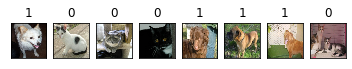

```python
for image, label in sub_dataset:
    fig, axs = plt.subplots(1,batch_size)
    for i in range(batch_size):
        axs[i].set_title(label.numpy()[i])
        axs[i].imshow(image.numpy()[i])
        axs[i].set_xticks([])#不显示坐标
        axs[i].set_yticks([])
plt.show()
```

## Dataset.shuffle(buffer_size),将源数据中的前buffer_size个数据取出来并打乱

## Dataset.batch(batch_size),将数据集分批次，即首先将原数据中前将batch_size个数据放在一起，再将剩下的数据中的前batch_size个数据放在一起，一直到分完

```python
###  将上述的步骤整合成一个函数
def prepara_dataset(data_dir,buffer_size,batch_size):
    filenames, labels = read_image_filenames(data_dir)
    dataset = tf.data.Dataset.from_tensor_slices((filenames, labels))
    dataset = dataset.map(
          map_func=decode_image_and_resize,
          num_parallel_calls = tf.data.experimental.AUTOTUNE)
    dataset = dataset.shuffle(buffer_size)
    dataset = dataset.batch(batch_size)
    dataset = dataset.prefetch(tf.data.experimental.AUTOTUNE)##预取几个元素出来，加快处理过程，(几个是根据程序自己定的)

    return dataset
```

```python
train_data_dir = "D:/Gog_VS_Cat/PetImages/"
buffer_size = 2002
batch_size = 8
dataset_train = prepara_dataset(train_data_dir,buffer_size,batch_size)
```

```python
sub_dataset = dataset_train.take(1)
```

```python
sub_dataset
```

```
<TakeDataset shapes: ((None, 224, 224, None), (None,)), types: (tf.float32, tf.int32)>
```

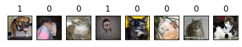

```python
for image, label in sub_dataset:
    fig, axs = plt.subplots(1,batch_size)
    for i in range(batch_size):
        axs[i].set_title(label.numpy()[i])
        axs[i].imshow(image.numpy()[i])
        axs[i].set_xticks([])#不显示坐标
        axs[i].set_yticks([])
plt.show()
```

## 迁移学习

[figure not shown]

#### 基于VGG16的迁移学习模型构建

```python
def vgg16_model(input_shape=(224,224,3)):
    vgg16 = tf.keras.applications.vgg16.VGG16(include_top = False,weights="imagenet",input_shape=input_shape)

    for layer in vgg16.layers:
        layer.trainable = False #设置VGG-16模型中的参数不可被训练

    last = vgg16.output
    #加入剩下的未训练的全连接层
    x = tf.keras.layers.Flatten()(last)
    x = tf.keras.layers.Dense(128,activation="relu")(x)
    x = tf.keras.layers.Dropout(0.3)(x)#预防过拟合，将里面的30%参数丢掉
    x = tf.keras.layers.Dense(32,activation="relu")(x)
    x = tf.keras.layers.Dropout(0.3)(x)
    x = tf.keras.layers.Dense(2,activation="softmax")(x)

    model = tf.keras.models.Model(inputs=vgg16.input,outputs=x)

    return model
```

```python
model = vgg16_model()
model.summary()
```

```
Model: "model_2"
_________________________________________________________________
Layer (type)                 Output Shape              Param #
=================================================================
input_6 (InputLayer)         [(None, 224, 224, 3)]     0
_________________________________________________________________
block1_conv1 (Conv2D)        (None, 224, 224, 64)      1792
_________________________________________________________________
block1_conv2 (Conv2D)        (None, 224, 224, 64)      36928
_________________________________________________________________
block1_pool (MaxPooling2D)   (None, 112, 112, 64)      0
_________________________________________________________________
block2_conv1 (Conv2D)        (None, 112, 112, 128)     73856
_________________________________________________________________
block2_conv2 (Conv2D)        (None, 112, 112, 128)     147584
_________________________________________________________________
block2_pool (MaxPooling2D)   (None, 56, 56, 128)       0
_________________________________________________________________
block3_conv1 (Conv2D)        (None, 56, 56, 256)       295168
_________________________________________________________________
block3_conv2 (Conv2D)        (None, 56, 56, 256)       590080
_________________________________________________________________
block3_conv3 (Conv2D)        (None, 56, 56, 256)       590080
_________________________________________________________________
block3_pool (MaxPooling2D)   (None, 28, 28, 256)       0
_________________________________________________________________
block4_conv1 (Conv2D)        (None, 28, 28, 512)       1180160
_________________________________________________________________
block4_conv2 (Conv2D)        (None, 28, 28, 512)       2359808
_________________________________________________________________
block4_conv3 (Conv2D)        (None, 28, 28, 512)       2359808
_________________________________________________________________
block4_pool (MaxPooling2D)   (None, 14, 14, 512)       0
_________________________________________________________________
block5_conv1 (Conv2D)        (None, 14, 14, 512)       2359808
_________________________________________________________________
block5_conv2 (Conv2D)        (None, 14, 14, 512)       2359808
_________________________________________________________________
block5_conv3 (Conv2D)        (None, 14, 14, 512)       2359808
_________________________________________________________________
block5_pool (MaxPooling2D)   (None, 7, 7, 512)         0
_________________________________________________________________
flatten_3 (Flatten)          (None, 25088)             0
_________________________________________________________________
dense_9 (Dense)              (None, 128)               3211392
_________________________________________________________________
dropout_6 (Dropout)          (None, 128)               0
_________________________________________________________________
dense_10 (Dense)             (None, 32)                4128
_________________________________________________________________
dropout_7 (Dropout)          (None, 32)                0
_________________________________________________________________
dense_11 (Dense)             (None, 2)                 66
=================================================================
Total params: 17,930,274
Trainable params: 3,215,586
Non-trainable params: 14,714,688
_________________________________________________________________
```

```python
#模型设置
model.compile(optimizer="adam",loss="sparse_categorical_crossentropy",metrics=["accuracy"])
```

```python
#进行训练
training_epoch=10
train_fit=model.fit(dataset_train,epochs=training_epoch,verbose=1)
```

```
Train for 251 steps
```

```python
##模型结构存储,下次就不用在训练了 pip install pyyaml
yaml_string = model.to_yaml()
with open("D:/Gog_VS_Cat/cat_dog.yaml","w") as model_file:
    model_file.write(yaml_string)
```

```python
##存储模型的参数
model.save_weights("D:/Gog_VS_Cat/cat_dog.h5")
```

```python
from tensorflow.keras.preprocessing import image
```

```python
import numpy as np
def read_image_files(path,start,finish,image_size=(224,224)):
    test_files = os.listdir(path)
    test_images=[]
    ##读取测试图片并预处理
    for fn in test_files[start:finish]:
        img_filename = path+fn
        img=image.load_img(img_filename,target_size=image_size)
        img_array=image.img_to_array(img)
        test_images.append(img_array)
    test_data = np.array(test_images)
    test_data/=255.0

    return test_data
```

```python
def test_image_predict(path,start,finish,image_size=(224,224)):
    test_data = read_image_files(path,start,finish,image_size=(224,224))
    preds = model.predict(test_data)
    for i in range(0,finish-start):
        if np.argmax(preds[i])==0:
            label="Predict: Cat; "+"Probability: "+str(preds[i][0])
        else:
            label="Predict: Dog; "+"Probability: "+str(preds[i][1])
        plt.title(label)
        plt.imshow(test_data[i])
        plt.axis("off")
        plt.show()
```

[figure not shown]

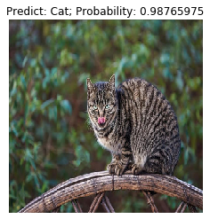

[figure not shown]

[figure not shown]

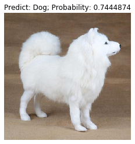

[figure not shown]

```python
test_data_dir="D:/Gog_VS_Cat/PetImages/test/"
test_image_predict(test_data_dir,0,6)
```